# Regresion

# Tarea 3.

# Completada por: Karen Bolaños Alfaro

# Regresión lineal

Análisis del Problema

El desempeño de un automóvil se puede medir de diferentes formas. Algunas comunes son la cantidad de caballos de fuerza y el rendimiento del mismo, que se puede resumir en cuantas millas puede recorrer el automóvil por cada galón de combustible que consume. Para los clientes, potenciales compradores de un automóvil, este rendimiento es importante pues puede ayudar a tomar una decisión con respecto a cuál automóvil comprar (si, por ejemplo, el cliente quiere un auto que rinda por muchas millas y pueda economizar en la compra de combustible).

Desde este punto de vista, tanto a clientes como a fabricadores de automóviles, les conviene entender cuál es la relación entre diferentes características del automóvil y su rendimiento, pues el conocer estas relaciones les puede ayudar a inferir cuál va a ser la eficiencia del vehículo a partir de ver los valores de otras características. Para fabricantes, puede ser importante conocer estas relaciones para saber cómo hacer cada modelo más eficiente con respecto al anterior.

Entendimiento de los Datos

Con el fin de analizar y tratar de estimar las millas por galón de diferentes modelos de automóviles, se trabajó con un conjunto de datos que contiene 398 observaciones y 9 variables:

- mpg (millas por galón): numérica, con un rango de 9 a 46.60.
- cyl (cilindraje): categórica ordinal, con valores posibles de 3, 4, 5, 6 y 8.
- disp (desplazamiento): numérica, con un rango de 68 a 455.
- hp (caballos de fuerza): numérica, con un rango de 46 a 230 y 6 valores faltantes.
- weight (peso): numérica, con un rango de 1613 a 5140.
- acc (aceleración): numérica, con un rango de 8 a 24.80.
- model year (año): categórica, con 13 valores diferentes representando el año del automóvil.
- origin (origen): categórica, 3 valores posibles: 1, 2, 3.
- model name (nombre del modelo): categórica, con 305 posibles valores.

```r
library(readr)
library(GGally)
library(caTools)
library(lessR)
library(visdat)
library(dplyr)
```

# Ejercicios

1. Cargue el archivo auto-mpg_g.csv en una variable

```r
autos <- read.csv('auto-mpg_g.csv')
```

2. Utilizando Ggpairs cree un gráfico de los atributos del dataset, observe las correlaciones entre atributos

Hagamos un ggpairs con todas las variables del dataset.  
Para generar este grafico no se grafica la variable model.name porque supera la cardinalidad permitida de 15.  
Como es categorica no nos aporta valor y no la vamos a graficar.

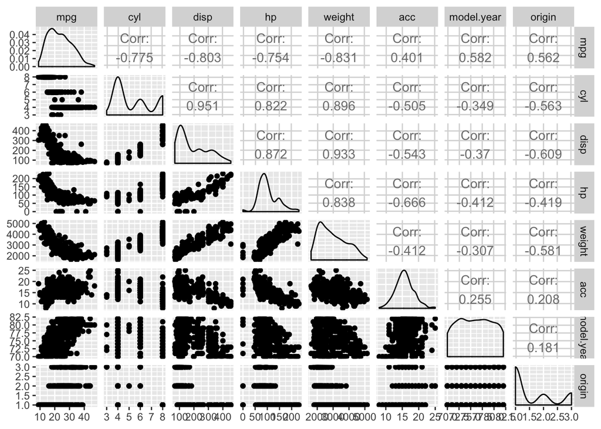

```r
ggpairs(autos[-9], progress = F)
```

Como se puede observar, tenemos varias variables categoricas que para aplicar regresion lineal, no nos van a aportar mucho valor, por ejemplo: origin, cyl, model.year, model.name

Hagamos un ggpair de nuevo pero sin esas variables categoricas: cyl, model.year, model.name y origin  
Se observa que solo la variable acc presenta una distribucion masomenos normal.

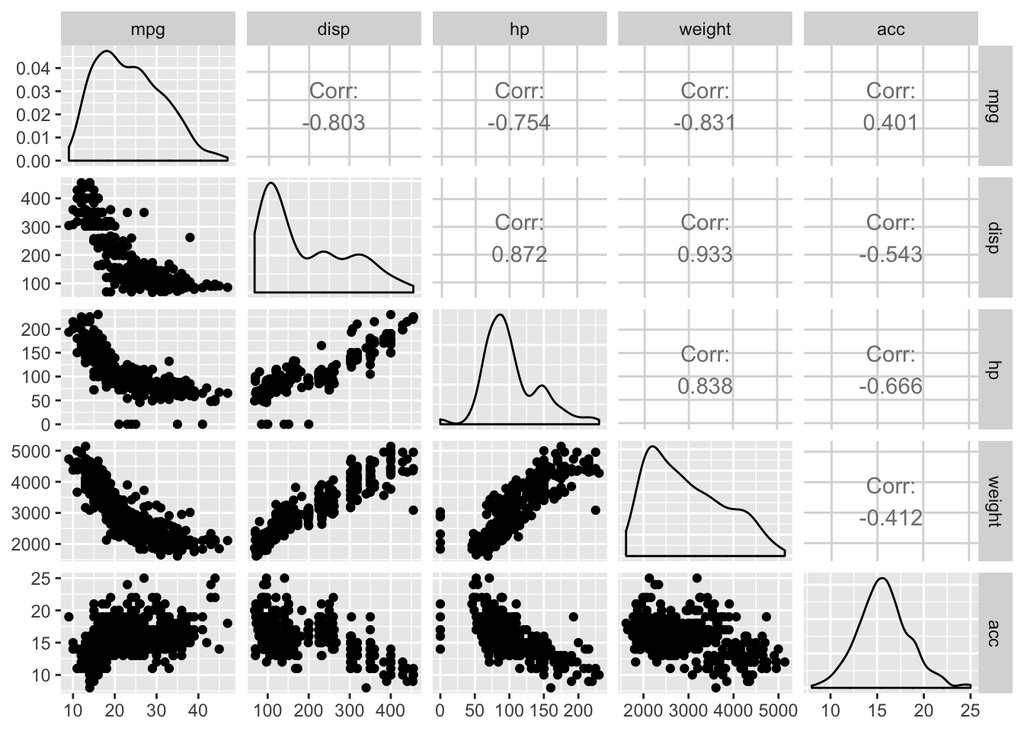

```r
ggpairs(autos[-c(2, 7,8,9)], progress = F)
```

Un vistazo rapido a las estadisticas de las variables del set de datos.

IMPORTANTE: no tenemos valores faltantes como NA, pero los tenemos en 0 para la columna hp, hay que hacer algo con ellos probemos con eliminarlos a ver que pasa, si no los eliminamos o tratamos, no podemos aplicar log sobre ellos.

```r
summary(autos)
```

```
##       mpg             cyl             disp             hp
##  Min.   : 9.00   Min.   :3.000   Min.   : 68.0   Min.   :  0.0
##  1st Qu.:18.00   1st Qu.:4.000   1st Qu.:104.2   1st Qu.: 75.0
##  Median :23.00   Median :4.000   Median :148.5   Median : 92.0
##  Mean   :23.56   Mean   :5.455   Mean   :193.4   Mean   :102.9
##  3rd Qu.:29.00   3rd Qu.:8.000   3rd Qu.:262.0   3rd Qu.:125.0
##  Max.   :47.00   Max.   :8.000   Max.   :455.0   Max.   :230.0
##
##      weight          acc          model.year        origin
##  Min.   :1613   Min.   : 8.00   Min.   :70.00   Min.   :1.000
##  1st Qu.:2224   1st Qu.:14.00   1st Qu.:73.00   1st Qu.:1.000
##  Median :2804   Median :16.00   Median :76.00   Median :1.000
##  Mean   :2970   Mean   :15.71   Mean   :76.01   Mean   :1.573
##  3rd Qu.:3608   3rd Qu.:17.00   3rd Qu.:79.00   3rd Qu.:2.000
##  Max.   :5140   Max.   :25.00   Max.   :82.00   Max.   :3.000
##
##            model.name
##   ford pinto    :  6
##   amc matador   :  5
##   ford maverick :  5
##   toyota corolla:  5
##   amc gremlin   :  4
##   amc hornet    :  4
##  (Other)        :369
```

3. Separe los datos en 2 conjuntos, uno de entrenamiento y otro de pruebas. Normalmente se trabaja utilizando un 70-80% de los datos para entrenamiento y el resto para pruebas.

Recuerde fijar una semilla para que el documento sea reproducible.

Pista: https://www.rdocumentation.org/packages/caTools/versions/1.17.1/topics/sample.split

Voy a crear un dataset nuevo basado en el anterior donde elimino las variables categoricas porque no me aportan valor y me dan problema en los calculos y voy a eliminar las filas que tienen hp en 0.

```r
autos_2 <- autos %>%
    select(mpg,disp,hp,weight,acc) %>%
    filter(hp > 0)
```

Veamos los tipos de datos y si falta alguno en el nuevo set de datos  
- Observamos que todos los datos que tenemos son de tipo integer y que no tenemos NA.

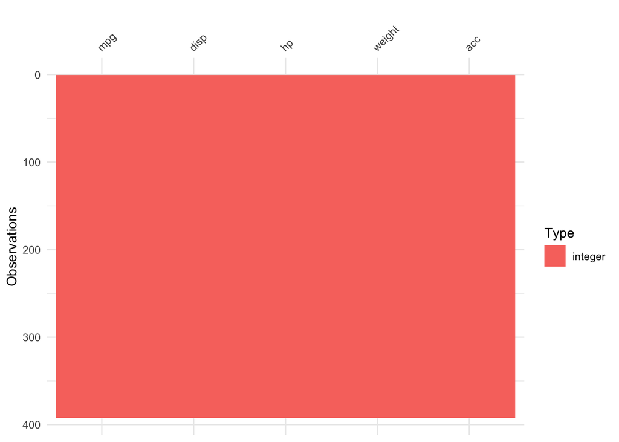

```r
vis_dat(autos_2)
```

```r
# no tenemos valores faltantes en el training set
sum(is.na(autos_2))
```

```
## [1] 0
```

### Histograma y graficos de densidad del nuevo data set

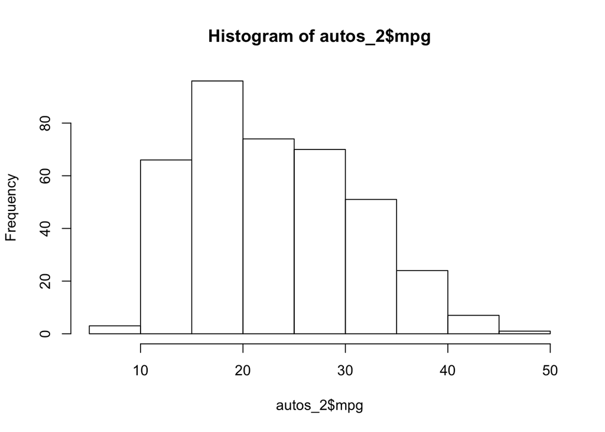

```r
hist(autos_2$mpg)
```

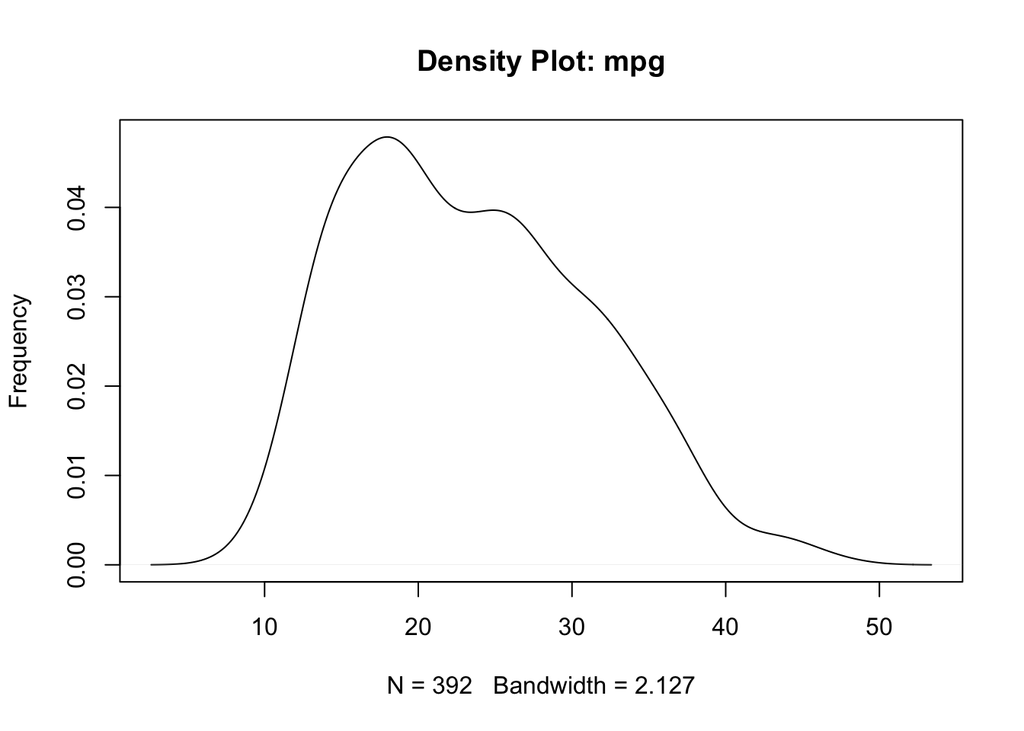

```r
plot(density(autos_2$mpg), main = "Density Plot: mpg", ylab = "Frequency")
```

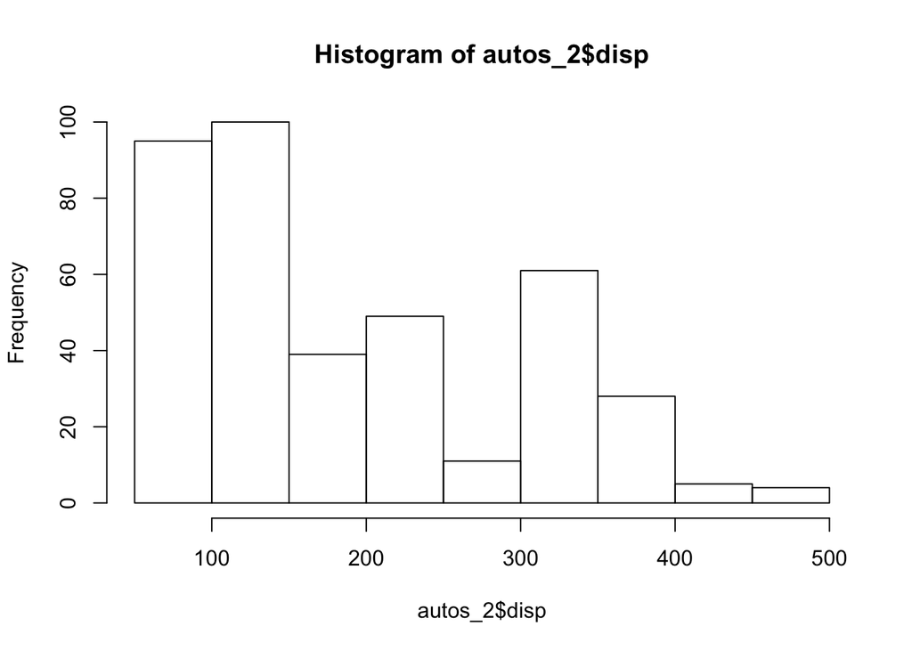

```r
hist(autos_2$disp)
```

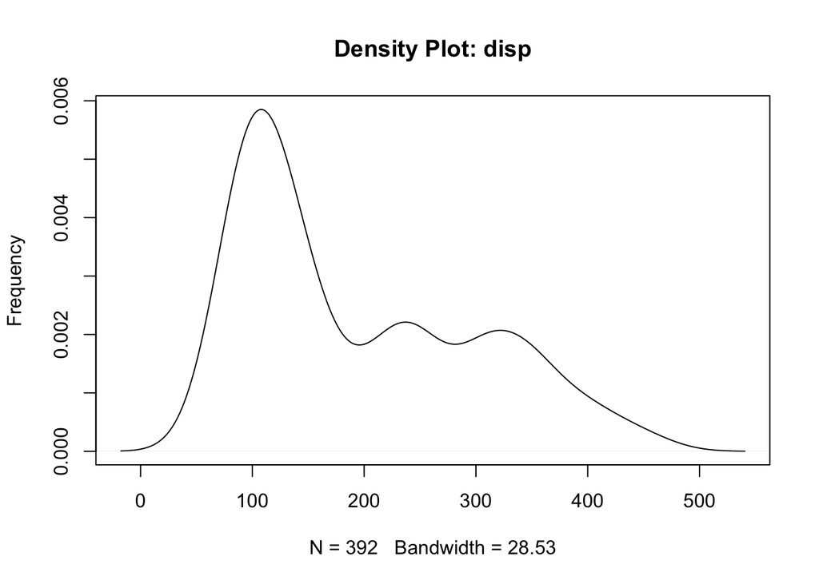

```r
plot(density(autos_2$disp), main = "Density Plot: disp", ylab = "Frequency")
```

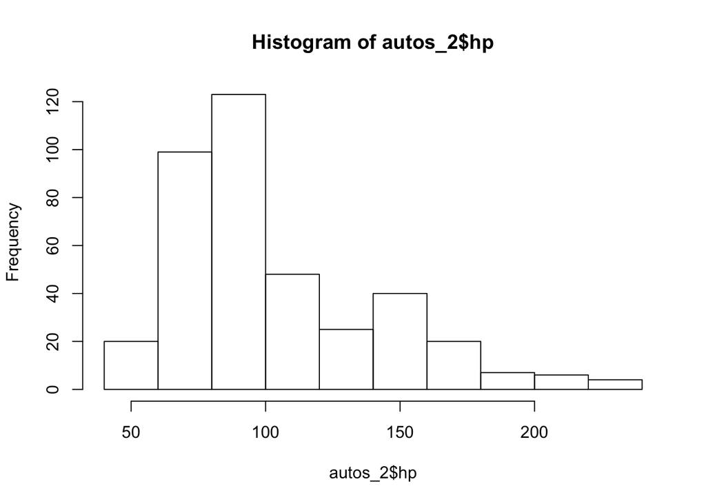

```r
hist(autos_2$hp)
```

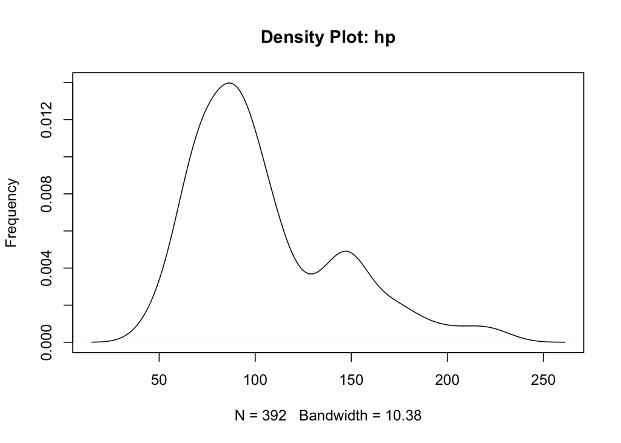

```r
plot(density(autos_2$hp), main = "Density Plot: hp", ylab = "Frequency")
```

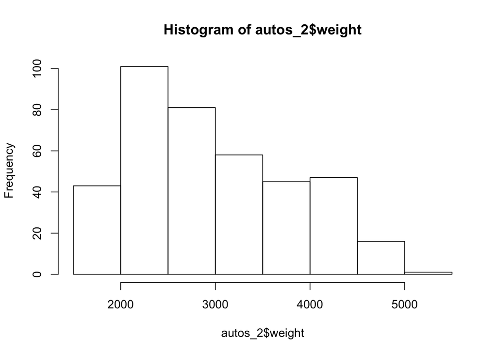

```r
hist(autos_2$weight)
```

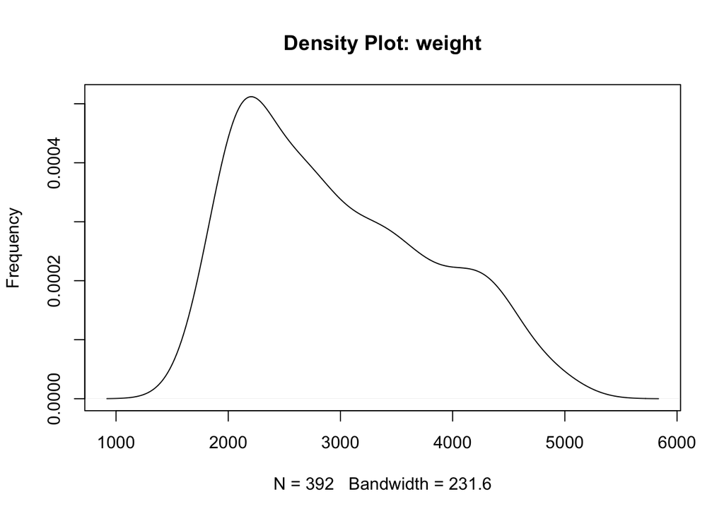

```r
plot(density(autos_2$weight), main = "Density Plot: weight", ylab = "Frequency")
```

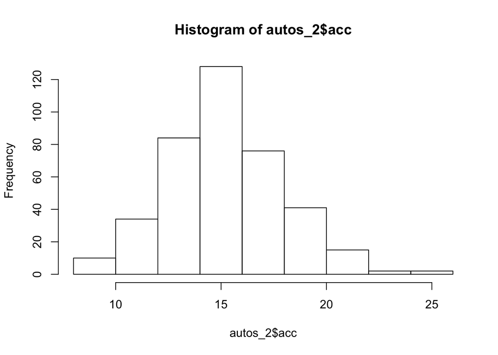

```r
hist(autos_2$acc)
```

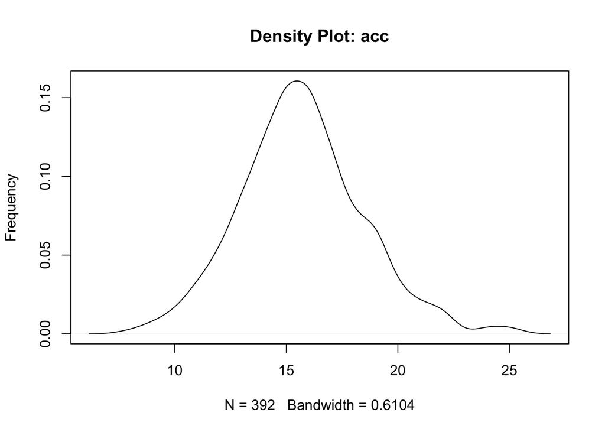

```r
plot(density(autos_2$acc), main = "Density Plot: acc", ylab = "Frequency")
```

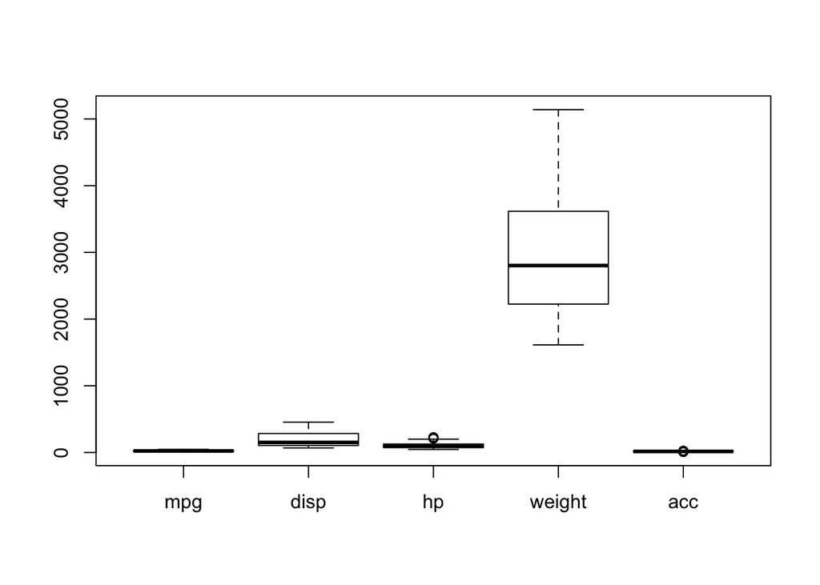

```r
# boxplot de todo el dataframe
boxplot(autos_2)
```

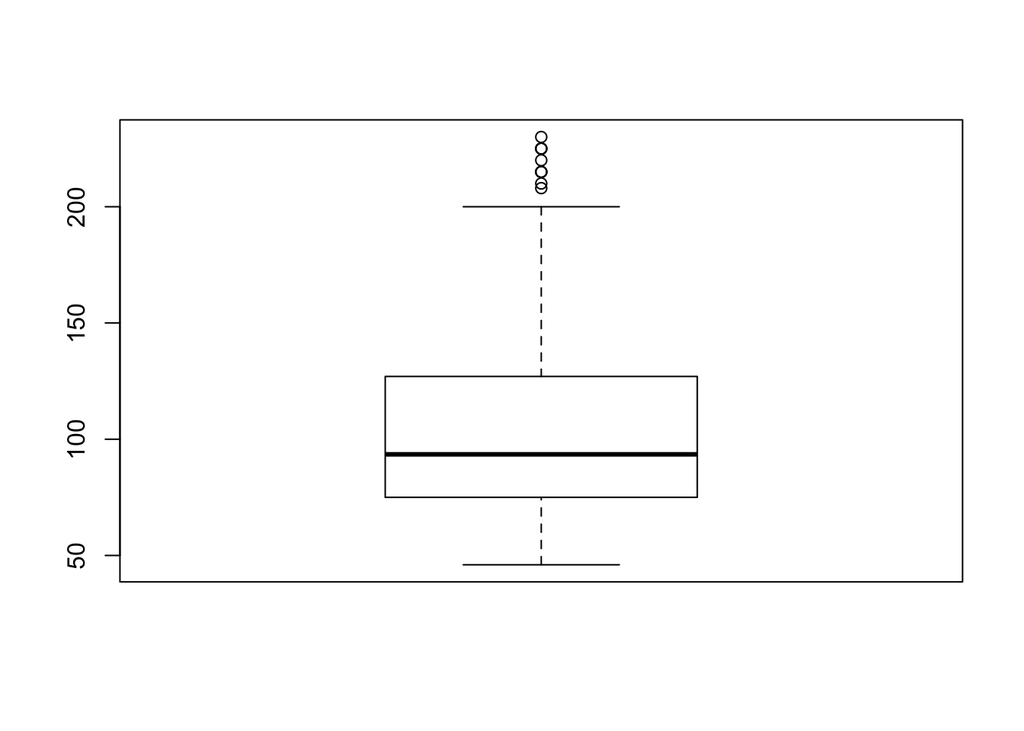

```r
# tenemos outliers en HP
boxplot(autos_2$hp)
```

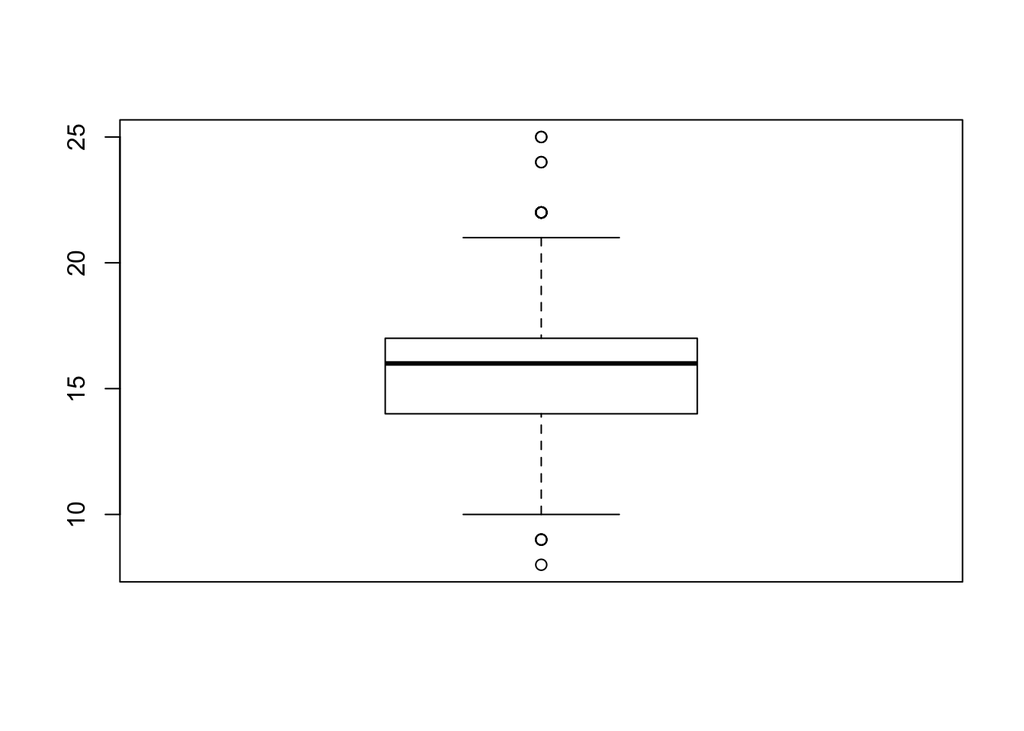

```r
# tenemos outliers en acc
boxplot(autos_2$acc)
```

Voy a repartir el 80% de los datos al set de training y el 20% al de pruebas

```r
set.seed(17)
data_split <- sample.split(autos_2, SplitRatio = 0.8)

training_set = subset(autos_2, data_split == TRUE)
test_set  = subset(autos_2, data_split == FALSE)
```

4. Cree un modelo de regresion lineal utilizando el atributo mpg como la variable objetivo y en base a las correlaciones observadas en el gráfico del punto 2 escoja al menos dos atributos para usarlos como variables predictoras para el modelo.

Pista: https://www.rdocumentation.org/packages/lessR/versions/1.9.8/topics/reg

Nota: Al crear el modelo utilice el conjunto de datos de entrenamiento definido en el punto 3.

Para esta paso mis variables predictoras del modelo seran: disp y hp

Aplicamos la formula con las variables predictoras en la regresion lineal.

```r
# reg(mpg ~ hp + disp, data = training_set)
```

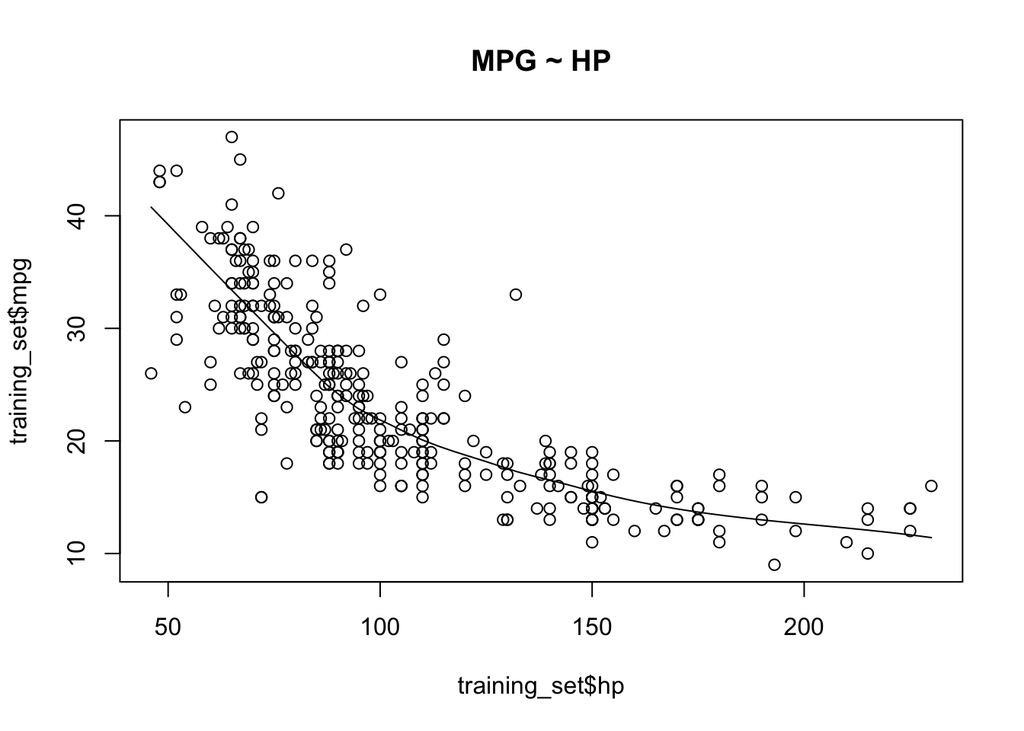

```r
scatter.smooth(x = training_set$hp, y = training_set$mpg, main = "MPG ~ HP")
```

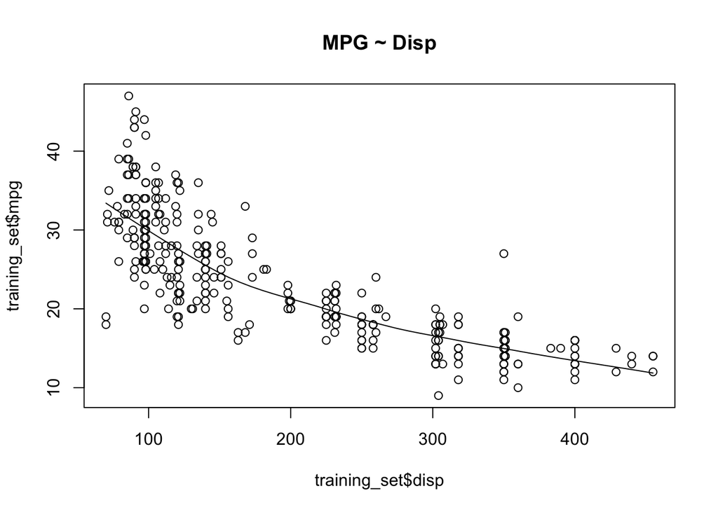

```r
scatter.smooth(x = training_set$disp, y = training_set$mpg, main = "MPG ~ Disp")
```

## hagamos regresion lineal con el comando lm

```r
linear_reg = lm(mpg ~ hp + disp, data = training_set)
print(linear_reg)
```

```
##
## Call:
## lm(formula = mpg ~ hp + disp, data = training_set)
##
## Coefficients:
## (Intercept)           hp         disp
##    37.42699     -0.05122     -0.04357
```

```r
summary(linear_reg)
```

```
##
## Call:
## lm(formula = mpg ~ hp + disp, data = training_set)
##
## Residuals:
##     Min      1Q  Median      3Q     Max
## -11.767  -3.196  -0.488   2.531  16.650
##
## Coefficients:
##              Estimate Std. Error t value             Pr(>|t|)
## (Intercept) 37.426987   0.840073  44.552 < 0.0000000000000002
## hp          -0.051222   0.015803  -3.241              0.00132
## disp        -0.043573   0.005798  -7.515    0.000000000000617
##
## Residual standard error: 4.653 on 310 degrees of freedom
## Multiple R-squared:  0.6597, Adjusted R-squared:  0.6575
## F-statistic: 300.4 on 2 and 310 DF,  p-value: < 0.00000000000000022
```

Hagamos ahora la prediccion del modelo

```r
predict_results <- predict(linear_reg,  test_set)
preds_comparison <- data.frame(cbind(actuals = test_set$mpg,
                                  predicteds = predict_results))
preds_comparison
```

|  | actuals | predicteds |
| --- | --- | --- |
| 2 | 15 | 13.724904 |
| 7 | 14 | 6.376134 |
| 12 | 14 | 14.416741 |
| 17 | 18 | 23.787483 |
| 22 | 24 | 28.154743 |
| 27 | 10 | 13.805786 |
| 32 | 25 | 27.637198 |
| 37 | 18 | 22.195911 |
| 42 | 12 | 11.518674 |
| 47 | 19 | 21.411599 |

[output cut: 69 more lines]

5. Realice predicciones utilizando el conjunto de pruebas y evalue el resultado con la métrica MSE.

Pista: https://www.rdocumentation.org/packages/mltools/versions/0.3.5/topics/mse

```r
#library(Metrics)
library(mltools)

# voy a predecir el error basada en mi nuevo dataframe preds_comparison
mse(preds = preds_comparison$predicteds, actuals = preds_comparison$actuals)
```

```
## [1] 16.66146
```

Obtenemos un MSE de 16.66146, sin aplicar ningun tratamiendo a las variables predictoras ni a la independiente.

6. Opcional

6.a Pruebe varios modelos que utilicen diferentes variables y comparar los resultados obtenidos

6.b Investigar como implementar en R las técnicas de preprocesado y normalización vistas en clase y aplicarlas a los datos antes de pasarlos al modelo.

# Prueba 1: probando con hp y disp aplicando log natural

El error ha bajado con respecto a la primera prueba sin aplicar log, ahora tenemos el MSE en: 15.65637

```r
linear_reg2 = lm(log(mpg) ~ log(hp) + log(disp), data = training_set)

# calcular predicciones
results2 <- predict(linear_reg2,  test_set)
predicted_2 <- data.frame(cbind(actuals = test_set$mpg,
                                  predicteds = exp(results2)))

# calculo del error
mse(preds = predicted_2$predicteds, actuals = predicted_2$actuals)
```

```
## [1] 15.65637
```

# Prueba 2: probando con weight y acc en su estado natural

El error ha bajado con respecto a la ultima prueba, ahora tenemos el MSE en: 15.03812

```r
# aplicar modelo
linear_reg3 = lm(mpg ~ weight + acc, data = training_set)

# calcular predicciones
results3 <- predict(linear_reg3,  test_set)
predicted_3 <- data.frame(cbind(actuals = test_set$mpg,
                                  predicteds = results3))

# calculo del error
mse(preds = predicted_3$predicteds, actuals = predicted_3$actuals)
```

```
## [1] 15.03812
```

# Prueba 3:probando con weight y acc con log

Aumenta el MSE: 16.32081

```r
# aplicar modelo
linear_reg4 = lm(log(mpg) ~ log(weight) + log(acc), data = training_set)

# calcular predicciones
results4 <- predict(linear_reg4,  test_set)
predicted_4 <- data.frame(cbind(actuals = test_set$mpg,
                                  predicteds = exp(results4)))

# calculo del error
mse(preds = predicted_4$predicteds, actuals = predicted_4$actuals)
```

```
## [1] 16.32081
```

# Prueba #4: probando con disp y weight en su estado natural

MSE: 15.50007

```r
# aplicar modelo
linear_reg5 = lm(mpg ~ disp + weight, data = training_set)

# calcular predicciones
results5 <- predict(linear_reg5,  test_set)
predicted_5 <- data.frame(cbind(actuals = test_set$mpg,
                                  predicteds = results5))
# calculo del error
mse(preds = predicted_5$predicteds, actuals = predicted_5$actuals)
```

```
## [1] 15.50007
```

# Prueba #5: probando con disp y weight con log

El MSE ha aumentado a 16.86141

```r
# aplicar modelo
linear_reg6 = lm(log(mpg) ~ log(disp) + log(weight), data = training_set)

# calcular predicciones
results6 <- predict(linear_reg6,  test_set)
predicted_6 <- data.frame(cbind(actuals = test_set$mpg,
                                  predicteds = exp(results6)))

# calculo del error
mse(preds = predicted_6$predicteds, actuals = predicted_6$actuals)
```

```
## [1] 16.86141
```

# Prueba #6: probando con acc y hp con log

MSE aumento a 18.55948

```r
# aplicar modelo
linear_reg7 = lm(log(mpg) ~ log(acc) + log(hp), data = training_set)

# calcular predicciones
results7 <- predict(linear_reg7,  test_set)
predicted_7 <- data.frame(cbind(actuals = test_set$mpg,
                                  predicteds = exp(results7)))

# calculo del error
mse(preds = predicted_7$predicteds, actuals = predicted_7$actuals)
```

```
## [1] 18.55948
```

# Prueba #7: probando con acc y hp en su estado natural

MSE: 17.00887

```r
# aplicar modelo
linear_reg8 = lm(mpg ~ acc + hp, data = training_set)

# calcular predicciones
results8 <- predict(linear_reg8,  test_set)
predicted_8 <- data.frame(cbind(actuals = test_set$mpg,
                                  predicteds = results8))

# calculo del error
mse(preds = predicted_8$predicteds, actuals = predicted_8$actuals)
```

```
## [1] 17.00887
```

# Prueba #8: probando con acc y hp con log en mpg

Aplicando log solo en la variable dependiente mpg obtengo el valor mas bajo con MSE de 14.24683

```r
# aplicar modelo
linear_reg9 = lm(log(mpg) ~ acc + hp, data = training_set)

# calcular predicciones
results9 <- predict(linear_reg9,  test_set)
predicted_9 <- data.frame(cbind(actuals = test_set$mpg,
                                  predicteds = exp(results9)))

# calculo del error
mse(preds = predicted_9$predicteds, actuals = predicted_9$actuals)
```

```
## [1] 14.24683
```

# Prueba #9: probando con disp y hp con log en mpg y hp

```r
# aplicar modelo
linear_reg10 = lm(log(mpg) ~ disp + log(hp), data = training_set)

# calcular predicciones
results10 <- predict(linear_reg10,  test_set)
predicted_10 <- data.frame(cbind(actuals = test_set$mpg,
                                  predicteds = exp(results10)))

# calculo del error
mse(preds = predicted_10$predicteds, actuals = predicted_10$actuals)
```

```
## [1] 14.48704
```

# Notas y dudas que me surgieron durante la realizacion de esta tarea: